# Cuaderno 1: RMarkdown

Aurora Baluja

24 de agosto de 2017

## Introducción a R Markdown

R es un potente lenguaje, desarrollado para ser usado en el ámbito de la estadística y el tratamiento de datos. Está basado en el lenguaje **S**, en el que también se basa SPSS.

Este es un documento RMarkdown. RMarkdown (o RMD) es un documento de texto simple. Este texto simple puede ser [**marcado**](http://rmarkdown.rstudio.com/authoring_basics.html) (“mark-down”), de forma que un intérprete lo pueda transformar en un documento más complejo, como un HTML (pag. web o “mark-up”) un PDF, o un documento de Word. Para más detalles, ver: http://rmarkdown.rstudio.com.

**Knitr** es un paquete desarrollado por Yihui Xie que permite generar un documento automáticamente usando Markdown y código R.

1. El documento RMD se generará al pulsar el botón **Knit**. Este documento RMD puede contener no sólo texto `marcado` , sino también código R y/o resultados del análisis del código R. Puedes poner código R dentro de estos conjuntos de caracteres:

```r
# aqui codigo R
1+1
```

```
## [1] 2
```

2. Dentro de las llaves, además de indicar qué lenguaje usamos (r), se pueden añadir [opciones](http://yihui.name/knitr/options/) que modifican cómo se muestra el código:

```
## [1] 2
```

3. Las opciones se separan por comas. Hay multitud de ellas, para todo tipo de necesidades.

```
[1] 3
```

4. Los resultados pueden estar tanto dentro de sus propias líneas en el texto, como insertados en una línea de texto simple. Por ejemplo, la suma del anterior comando es = 3. Esto hace que se puedan generar resultados de forma automática, sin tener que cambiar el texto.
5. Ejercicio 1: modifica este trozo de código para que muestre la multiplicación de los números 35 y 76, sin mostrar el código que ha generado el número:

```r
# aqui codigo R
```

## Mostrar gráficos

Existen un gran número de opciones para dar formato a los gráficos producidos por código R:

El tamaño de la imagen (altura y anchura) se programa en pulgadas.. (sic)

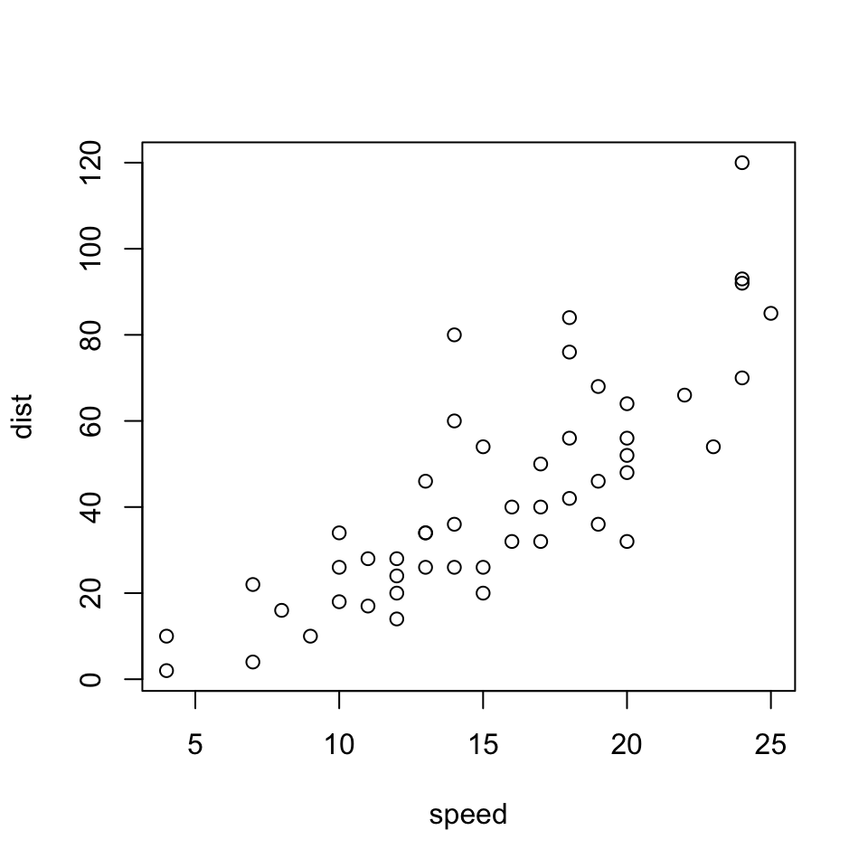

6. Ejercicio 2: modifica el tamaño de la imagen para que tenga 6 pulgadas de altura y 7 pulgadas (inches) de ancho.

## Títulos

### Y subtítulos

#### Y sub-sub títulos…

Para más opciones de formato, consultar [aquí.](https://www.rstudio.com/wp-content/uploads/2015/03/rmarkdown-reference.pdf)

## Marcado HTML en RMarkdown

RMarkdown también admite algunas etiquetas de marcado de texto típicas de las páginas web, como son las del color de letra, la sangría…

(texto centrado)

Para una paleta de colores completa, consulta este enlace: http://www.w3schools.com/colors/colors_picker.asp.

El color naranja, en este caso, es “#ff6600”.

Hecho artesanalmente con [RMarkdown](http://rmarkdown.rstudio.com)